# Guía de trabajo Introducción Variables Aleatorias

Análisis de datos con R para Biociencias

Dr. José A. Gallardo y Dra. María Angélica Rueda.

Pontificia Universidad Católica de Valparaíso  
jose.gallardo@pucv.cl

18 January 2022

#### **Introducción**

**¿Cuál es la diferencia entre variable y dato?**

Las **variables** son las características que se pueden medir en un individuo o en un ambiente y los **datos** son los valores que puede tomar esa variable.

**¿Qué es una variable aleatoria?**

Es una variable cuyo valor se determina por el azar. Las variables aleatorias se representan por letras mayúsculas (**X**) y sus valores numéricos por letras minúsculas ($x_i$).

#### **Objetivos de aprendizaje**

Los objetivos de aprendizaje de esta guía son:

**1**. Observar y predecir una variable aleatoria continua con distribución normal.

**2**. Observar y predecir el comportamiento de variables aleatorias discretas con distribución Bernoulli o Binomial.

**3**. Elaborar un reporte dinámico en formato pdf.

#### **Clasificación de variables cuantitativas**

[output not shown]

#### **Clasificación de variables cualitativas o categóricas**

| Tipo de variable | Descripción |
| --- | --- |
| **Variables nominales:** | Sus valores representan categorías que no obedecen a una clasificación intrínseca. |
| **Variables ordinales:** | Sus valores representan categorías con alguna clasificación intrínseca. |

### **Distribución de una variable**

*Distribución empírica (observación)*: Los datos de una muestra, obtenidos de forma aleatoria de una población, pueden ser usados para observar su comportamiento o distribución.

*Distribución de probabilidad (predicción)*: Las variables aleatorias tienen diferentes distribuciones de probabilidad subyacentes, lo que nos permite predecir su comportamiento y realizar inferencia estadística.

*Distribución normal*: Las variables cuantitativas continuas podrían seguir una distribución normal.

#### **¿Cómo puedo observar y predecir el comportamiento de una variable?**

**Funciones clave**

**1.-** Tabla de distribución de frecuencia  
**table()**

**2.-** Histograma  
**hist()**

**3.-** Gráfico x-y de puntos “p”, líneas “l” o ambas “b”.  
**plot()**

**4.-** Gráfico de cajas y bigotes  
**boxplot()**

**5.-** Gráfico de barras **barplot()**

**6.-** Mediante la función de densidad empírica **density()**

**7.-** Mediante la función de distribución acumulada empírica  
**ecdf()**

#### **¿Qué puedo medir de una variable aleatoria continua?**

**Funciones clave**

**1.-** *Medidas de tendencia central*:

media **mean()** y mediana **median()**.

**2.-** *Medidas de dispersión*:

varianza **var()**, desviación estándar **sd()**, rango **range()**.

**3.-** *Concentración de datos en cuantiles*.

**quantile()**.

**4.-** *Función de distribución de probabilidad acumulada Bernoulli*.

**pbern()**.

**5.-** *Función de densidad de probabilidad Bernoulli*.

**dbern()**.

**6.-** *Función para hallar los cuantiles de una Bernoulli*.

**qbern()**.

**7.-** *Función de distribución de probabilidad acumulada Binomial*.

**pbinom()**.

**8.-** *Función de densidad de probabilidad Binomial*.

**dbinom()**.

**9.-** *Función para hallar los cuantiles de una Binomial*.

**qbinom()**.

*¿Cómo puedo simular números aleatorios con distribución Binomial y Bernoulli?*

**10.-** Simular variable aleatoria Bernoulli.

**rbern()**.

**11.-** Simular variable aleatoria Binomial.

**rbinom()**.

#### **Librerías a usar en esta guía**

**{stats}** , **{graphics}**, **{readxl}**, **{pander}**, **{MASS}**, **{Rlab}**.

## **Ejercicios**

### **Ejercicio 1.** **Elaborar un Script de R (Archivo .R)**

Elabore un archivo o file con extensión **.R** usando la barra de herramientas de **Rstudio**. Selecciona **File > New file > R script**. Utilice el siguiente ejemplo para completar la información de **metadatos** del script.

```
# ----------------------------------------------------------
# Clase 2 - Script Introducción Variables Aleatorias.
# Su nombre.
# Fecha de hoy.
# Curso R para Biociencias.
# ----------------------------------------------------------
```

Luego, guarde inmediatamente su script como **script_1_nombre_apellido.R**. Al finalizar la actividad deberá exportar y almacenar este *script* en su carpeta drive de tareas.

### **Ejercicio 2.** **Configuración del Script**

Debajo del **metadatos** instale las siguientes librerías **readxl**, **stats**, **graphics**, **pander**, **MASS** y **Rlab** con el comando **install.packages(“Nombre de la librería”)** o también podría instalar las librerías de forma directa haciendo click en la solapa **Packages** que se encuentra en la parte inferior derecha del Rstudio Cloud y colocar el nombre de las librerías a instalar, hacer este proceso para cada una de las librerías. Luego de tener instaladas las librerías cargelas con la función **library(Nombre de la librería)**.

```r
knitr::opts_chunk$set(echo = FALSE)
library(readxl)
library(stats)
library(graphics)
library(pander)
library(MASS)
library(Rlab)
```

### **Ejercicio 3.** **Importar y explorar datos**

El set de datos **Data.xlsx** contiene información de tamaño (Weight) de 200 animales, los cuales se clacificaron según su sexo en **male** o **female**.

Cree un objeto llamado **dat** e importe el set de datos **Data.xlsx** usando la función *read_excel()* de la librería **readxl**. Explore el set de datos usando las funciones **head()**, **tail**, **summary()** y **str()**.

```
## # A tibble: 6 × 3
##   sample_id Weight sex
##       <dbl>  <dbl> <chr>
## 1         1   17.2 female
## 2         2   18.8 female
## 3         3   27.8 male
## 4         4   20.4 male
## 5         5   20.6 male
## 6         6   28.6 male
```

```
## # A tibble: 6 × 3
##   sample_id Weight sex
##       <dbl>  <dbl> <chr>
## 1       195   13.4 female
## 2       196   30   male
## 3       197   23   male
## 4       198   13.7 female
## 5       199   16.9 female
## 6       200   14.1 female
```

```
##    sample_id          Weight          sex
##  Min.   :  1.00   Min.   : 8.50   Length:200
##  1st Qu.: 50.75   1st Qu.:16.90   Class :character
##  Median :100.50   Median :19.70   Mode  :character
##  Mean   :100.50   Mean   :19.96
##  3rd Qu.:150.25   3rd Qu.:22.82
##  Max.   :200.00   Max.   :36.20
```

```
## tibble [200 × 3] (S3: tbl_df/tbl/data.frame)
##  $ sample_id: num [1:200] 1 2 3 4 5 6 7 8 9 10 ...
##  $ Weight   : num [1:200] 17.2 18.8 27.8 20.4 20.6 28.6 22.3 13.7 16.6 17.8 ...
##  $ sex      : chr [1:200] "female" "female" "male" "male" ...
```

### **Ejercicio 4.** **Corrección de variables**

Note que en el ejercicio anterior la variable **sex** fue codificada como caracter o texto (chr) en vez de factor. Use la función **as.factor(dat$sex)** para indicar que sexo es un factor de clasificación. Vuelva a ejecutar los comandos **summary()** y **str()** para comprobar que las variables están adecuadamente codificadas.

```
##    sample_id          Weight          sex
##  Min.   :  1.00   Min.   : 8.50   female:100
##  1st Qu.: 50.75   1st Qu.:16.90   male  :100
##  Median :100.50   Median :19.70
##  Mean   :100.50   Mean   :19.96
##  3rd Qu.:150.25   3rd Qu.:22.82
##  Max.   :200.00   Max.   :36.20
```

```
## tibble [200 × 3] (S3: tbl_df/tbl/data.frame)
##  $ sample_id: num [1:200] 1 2 3 4 5 6 7 8 9 10 ...
##  $ Weight   : num [1:200] 17.2 18.8 27.8 20.4 20.6 28.6 22.3 13.7 16.6 17.8 ...
##  $ sex      : Factor w/ 2 levels "female","male": 1 1 2 2 2 2 2 1 1 1 ...
```

### **Ejercicio 5.** **Observar el comportamiento de una variable**

A partir del set de datos **dat** elabore un histograma y un boxplot de la variable cuantitativa continua **Weight**. Use las funciones **hist()**, **boxplot()**. Incluya títulos y leyenda de los ejes con los argumentos **col=““, main =”“** y **xlab=““**.

Investigue y use este comando **par(mfrow=c(1,2))** para unir las gráficas en un solo panel con dos columnas.

Investigue que representa el círculo que aparece en el Boxplot.

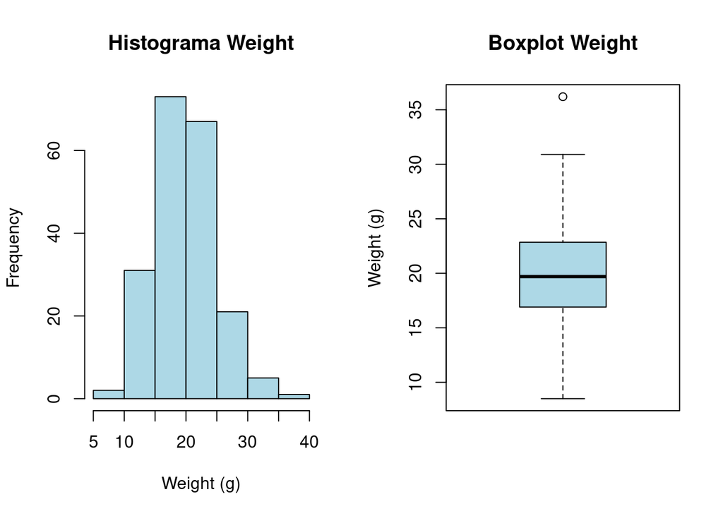

### **Ejercicio 6.** **Métricas del set de datos dat**

Calcule las siguientes métricas del set de datos: promedio, desviación estándar, rango y cuantiles usando las funciones: **mean()**, **sd()**, **range()** y **quantile()**.

```
## [1] 19.958
```

```
## [1] 4.710923
```

```
## [1]  8.5 36.2
```

```
##     0%    25%    50%    75%   100%
##  8.500 16.900 19.700 22.825 36.200
```

### **Ejercicio 7.** **Función de densidad**

Usando la función **plot()** elabore:

**a).** Gráfico con la densidad empírica. Debe incluir la función **density()** dentro de la función **plot()**.

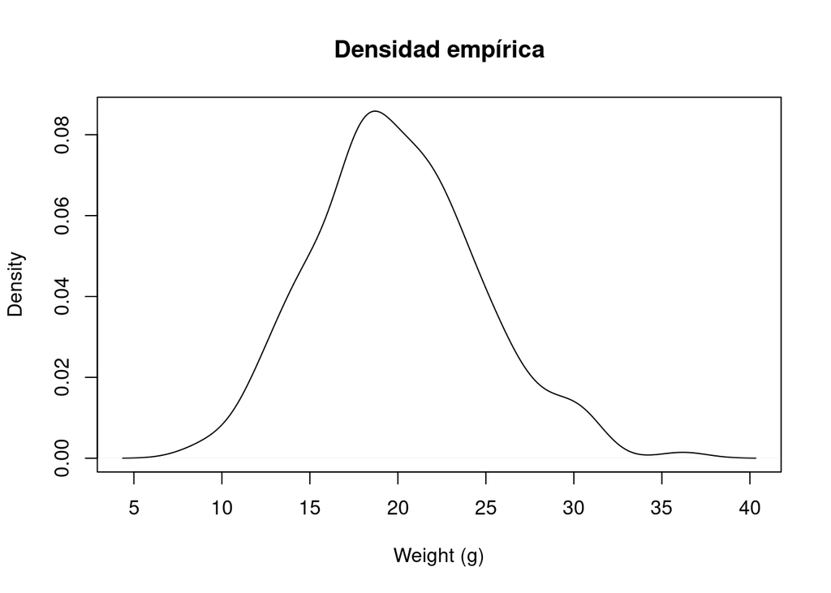

**b).** Gráfico con la distribución acumulada empírica. Debe incluir la función **ecdf()** dentro de la función **plot()**.

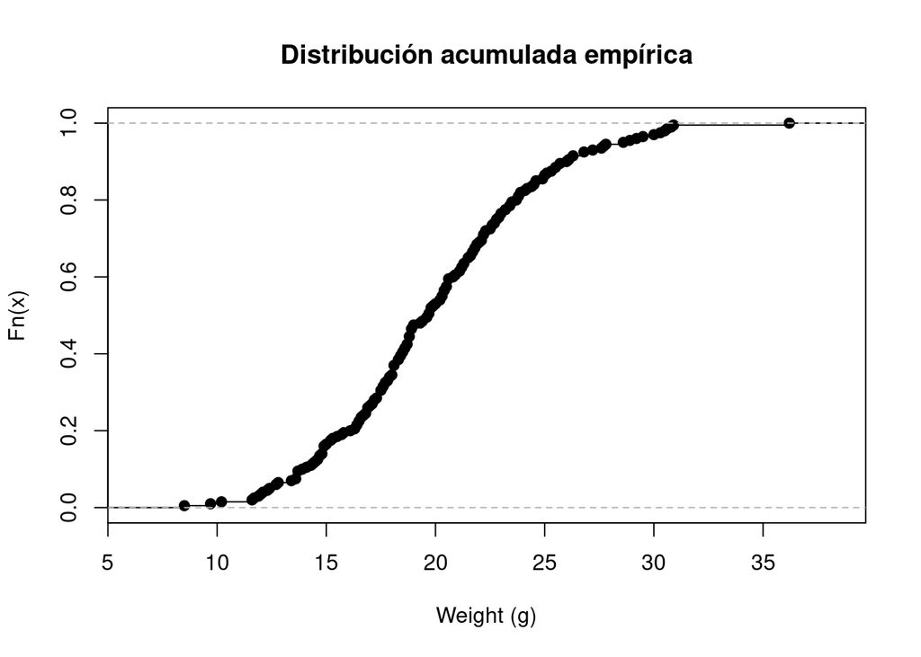

```r
# Distribución acumulada empírica.
plot(ecdf(dat$Weight), main="Distribución acumulada empírica", xlab="Weight (g)")
```

### **Ejercicio 8.** **Crear una función y predecir datos observados**

Utilice la función de distribución acumulada empírica **ecdf()** para determinar que proporción de los animales es menor a 20 g, y que proporción es mayor de 30 g:

**a).** Primero cree un un objeto llamado **Fn** con la función de distribución acumulada empírica para los datos del peso de sus animales.

```r
Fn <- ecdf(dat$Weight)
Fn
```

```
## Empirical CDF
## Call: ecdf(dat$Weight)
##  x[1:125] =    8.5,    9.7,   10.2,  ...,   30.9,   36.2
```

**b).** Calcule la proporción de animales menores de 20 g.

```
## [1] "La proporción de animales menores a 20 g es =53%"
```

**c).** Calcule la proporción de animales mayor a 30 g.

```r
# 1- Fn(x) returns 1 - the percentiles for x
paste0("La proporción de animales mayores a 30 g es =", ((1 - Fn(30))*100), "%")
```

```
## [1] "La proporción de animales mayores a 30 g es =3%"
```

### **Ejercicio 9.** **Proporción de datos entorno a la media**

En la siguiente figura, la línea roja representa 1 de sobre y bajo la media, la línea azul representa la media.

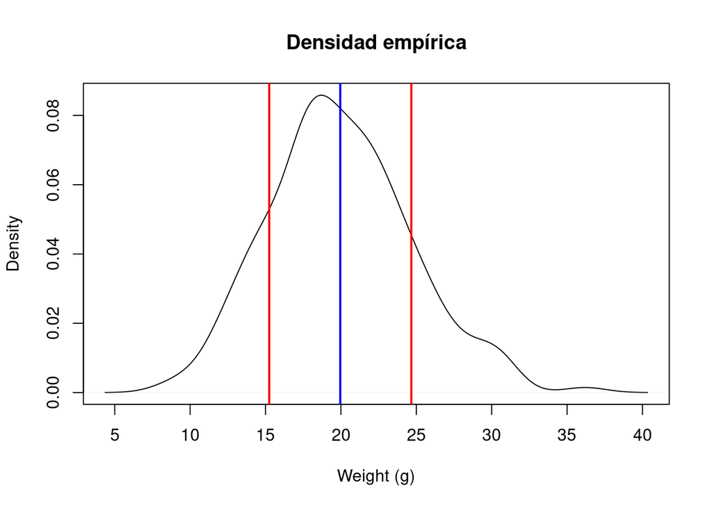

¿Qué proporción de los datos está contenido entre una desviación estándar hacia arriba y hacia abajo de la media?.

```
## [1] 0.15
```

```
## [1] 0.175
```

**c).** Calcule la proporción de datos entre 1 desviación estándar arriba y abajo de la media multiplicado por 100.

```
## [1] "67.5%"
```

### **Ejercicio 10.** **Variable aleatoria discreta (Distribución Binomial)**

Una empresa exportadora de productos marinos implementa un sistema de inspección visual de los productos, clasificándolos como defectuosos **(D)** y no defectuosos **(ND)**.

**a).** ¿Qué tipo de variable y distribución mejor representará al número de productos defectuosos?

**b).** Si en un proceso de inspección se detectó un total de 8 productos defectuosos y 24 no defectuosos. ¿Calcule cuál es la probabilidad de que los productos sean defectuosos?.

```
## [1] 0.25
```

**c).** ¿Calcule la probabilidad de que no sean defectuosos?

```
## [1] 0.75
```

**d).** El comprador en el extranjero desea comprobar que la información de origen de la proporción de producto defectuosa es correcta. Para ello toma una muestra aleatoria de solo 3 productos.

Responda las siguientes preguntas usando la información de la siguiente tabla relacionada al ejercicio 10:

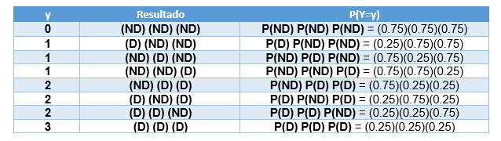

**e).** ¿Cuál es la probabilidad de que el comprador no detecte productos defectuosos?

```
## [1] 0.421875
```

**f).** ¿Cuál es la probabilidad de que detecte que todos los productos son defectuoso?

```
## [1] 0.015625
```

### **Ejercicio 11.** **Variable aleatoria discreta (Distribución Bernoulli)**

*Alexandrium catenella* es una microalga tóxica que produce el veneno paralizante de los mariscos (VPM). En Chile las intoxicaciones por VPM entre 1972-2002 generaron 456 enfermos y 30 fallecidos (total = 486). A partir de estos antecedentes responda.

**a).** ¿Calcule la letalidad por VPM en Chile?

```
## [1] 0.0617284
```

**b).** ¿Que tipo de variable y distribución mejor representa a la intoxicación por VPM?

**c).** Se ha reportado un intoxicación masiva de veneno paralizante de los mariscos en Calbuco que dió como resultado 80 personas intoxicadas. ¿Cuántas personas se recuperarán (0) y cuantas morirán (1) por esta intoxicación?.

Para responder primero nosotros crearemos un objeto para usted denominado **rvpm** y simularemos el resultado de la intoxicación usando la función **rbinom()**. Usaremos **print()** para observar los datos simulados.

```r
set.seed(123)
n <- 80
p <- 0.0617
q <- 1-p
rvpm<-rbinom(n, size=1, prob=0.0617)
print(rvpm)
```

```
##  [1] 0 0 0 0 1 0 0 0 0 0 1 0 0 0 0 0 0 0 0 1 0 0 0 1 0 0 0 0 0 0 1 0 0 0 0 0 0 0
## [39] 0 0 0 0 0 0 0 0 0 0 0 0 0 0 0 0 0 0 0 0 0 0 0 0 0 0 0 0 0 0 0 0 0 0 0 0 0 0
## [77] 0 0 0 0
```

**d).** Usando la función **table()** represente la frecuencia esperada de recuperados y fallecidos.

```
## rvpm
##  0  1
## 75  5
```

**e).** represente en un histograma la frecuencia de recuperados y fallecidos

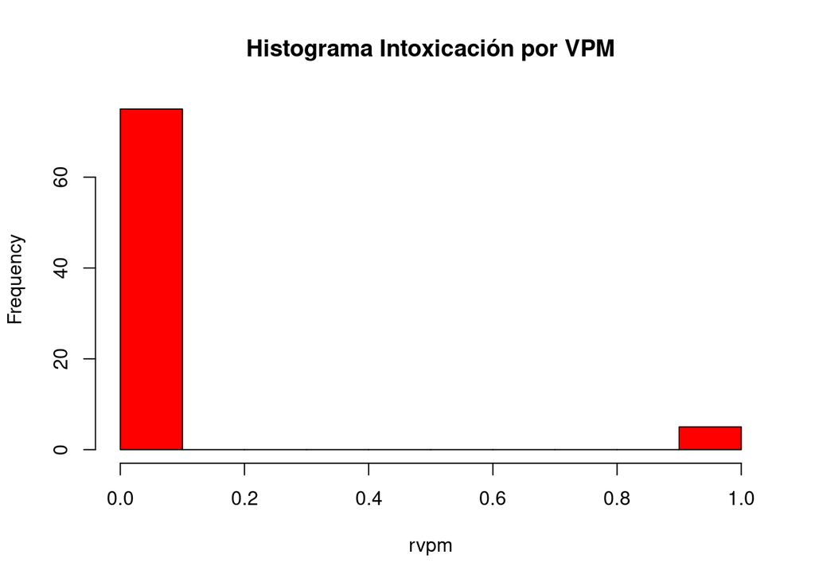

**f).** Investigue como se calcula el promedio y la varianza de una variable con distribución binomial. Calcule ambos parámetros para la población de estudio.

Promedio de fallecidos

```
## [1] 4.936
```

Varianza de fallecidos

```
## [1] 4.631449
```

**g).** Gráfique función de densidad de las intoxicaciones por VPM usando una la función plot. En el eje “x” grafique los datos simulados con rbinom() y en el eje “y” la función de densidad dbinom().

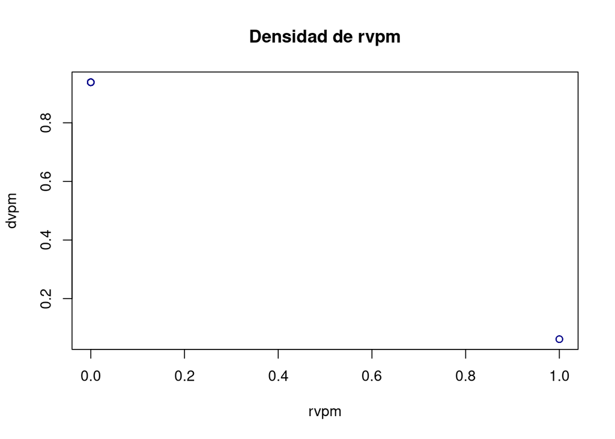

```r
dvpm<-dbinom(rvpm, size=1, prob=0.0617)
plot(x=rvpm, y=dvpm, main="Densidad de rvpm", col="blue4")
```

**h).** Gráfique la distribución de probabilidad acumulada de las intoxicaciones por VPM usando la función plot(). En el eje “x” grafique los datos simulados con rbinom() y en el eje “y” la probabilidad acumulada con pbinom().

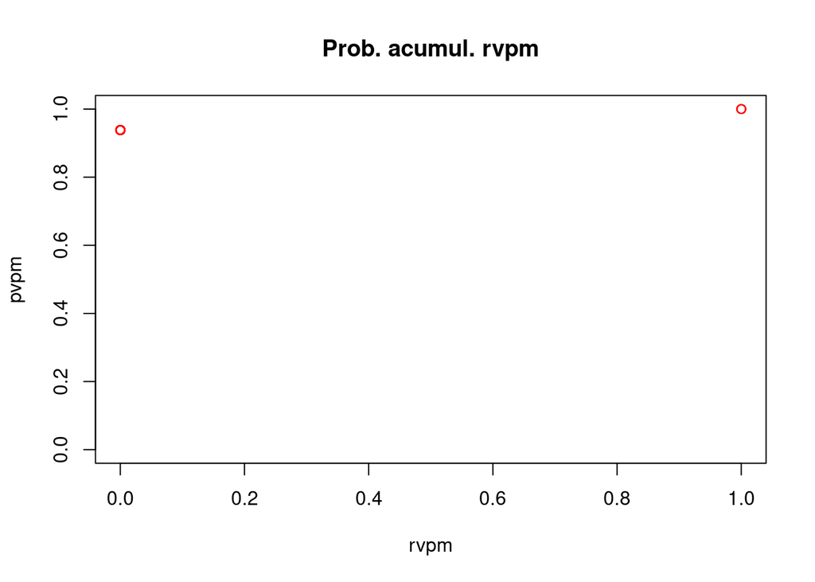